# ChicagoCrime_FinalProject

Harsh Bhatia

December 5, 2018

## Introduction

This data gives the crime rates in Chicago from the year 2001 to 2018. I obtained this dataset from the Chicago’s data portal *https://data.cityofchicago.org/Public-Safety/Crimes-2001-to-present-Dashboard/5cd6-ry5g.

The file is 1.48 GB in size and contains 6752938 observations for 22 variables.

I was in particular very curious to research about this dataset as Chicago was the first city I lived in after moving to United States. My stay in Chicago was around 3 month and I also have visited Chicago a number of times for personal and work reasons. Through this reaserach I wanted to get an idea of how Chicago was responding to the various efforts put in by authorities, mostly the police department, to make Chicago a safe city.

The dataset reflects the reported incidents of crime in the city of Chicago from the year 2001 to present. The data contains the reports only for the initial crime reported to the City of Chicago Police Department by sources that were not verified prior any investigations. The preliminary crime classification may have been changed at a later date, and there is a possible scope of human or mechanical error at any point in recording the information and through the duration of this research paper that may still be present.

```r
# reading the dataset
chicago <- read.csv("Crimes_-_2001_to_present.csv")

dim(chicago)
```

```
## [1] 6752938      22
```

```r
str(chicago)
```

```
## 'data.frame':    6752938 obs. of  22 variables:
##  $ ID                  : int  10000092 10000094 10000095 10000096 10000097 10000098 10000099 10000100 10000101 10000104 ...
##  $ Case.Number         : Factor w/ 6752534 levels "",".JB299184",..: 5757556 5757692 5757686 5757688 5757632 5757677 5757684 5757644 5757669 5757625 ...
##  $ Date                : Factor w/ 2702393 levels "01/01/2001 01:00:00 AM",..: 538445 538538 538530 538520 538478 538510 538538 538497 538512 538490 ...
##  $ Block               : Factor w/ 59914 levels "0000X E 100 PL",..: 36753 47515 34786 38952 36667 37660 49044 33643 29883 55886 ...
##  $ IUCR                : Factor w/ 401 levels "0110","0141",..: 31 360 53 41 19 41 53 53 258 41 ...
##  $ Primary.Type        : Factor w/ 35 levels "ARSON","ASSAULT",..: 3 26 3 3 31 3 3 3 19 3 ...
##  $ Description         : Factor w/ 379 levels "$300 AND UNDER",..: 41 258 138 316 54 316 138 138 274 316 ...
##  $ Location.Description: Factor w/ 180 levels "","ABANDONED BUILDING",..: 159 159 19 19 155 19 19 19 159 141 ...
##  $ Arrest              : Factor w/ 2 levels "false","true": 1 2 1 1 1 1 1 1 2 1 ...
##  $ Domestic            : Factor w/ 2 levels "false","true": 1 1 2 1 1 1 2 2 1 1 ...
##  $ Beat                : int  1111 725 222 225 1113 223 733 213 912 511 ...
##  $ District            : int  11 7 2 2 11 2 7 2 9 5 ...
##  $ Ward                : int  28 15 4 3 28 4 17 3 11 6 ...
##  $ Community.Area      : int  25 67 39 40 25 39 68 38 59 49 ...
##  $ FBI.Code            : Factor w/ 26 levels "01A","01B","02",..: 6 26 11 11 4 11 11 11 21 11 ...
##  $ X.Coordinate        : int  1144606 1166468 1185075 1178033 1144920 1183018 1170859 1178746 1164279 1179637 ...
##  $ Y.Coordinate        : int  1903566 1860715 1875622 1870804 1898709 1872537 1858210 1876914 1880656 1840444 ...
##  $ Year                : int  2015 2015 2015 2015 2015 2015 2015 2015 2015 2015 ...
##  $ Updated.On          : Factor w/ 2469 levels "01/01/2007 07:32:02 AM",..: 233 233 233 233 233 233 233 233 233 233 ...
##  $ Latitude            : num  41.9 41.8 41.8 41.8 41.9 ...
##  $ Longitude           : num  -87.7 -87.7 -87.6 -87.6 -87.7 ...
##  $ Location            : Factor w/ 860471 levels "","(36.619446395, -91.686565684)",..: 528656 232187 357597 325039 482403 337071 210400 364561 379558 79041 ...
```

## Data Cleaning

The original contains 22 variables with 6752938 observations and ranges from 2001 to present.

Out of the 22 variables I would select 4 variables that would most part of this project and help give a broader picture to the crime in Chicago.

1. Primary.Type: Gives us the type of crime that took place, later on we split into violent and non-violent crime
2. Arrest: Tells us if an arrest was made for the committed crime
3. District: District in the city of Chicago where the crime was committed
4. Year: The year in which the crime took place.

We are only going to use data recorded after the year 2008.

```r
names(chicago)
```

```
##  [1] "ID"                   "Case.Number"          "Date"
##  [4] "Block"                "IUCR"                 "Primary.Type"
##  [7] "Description"          "Location.Description" "Arrest"
## [10] "Domestic"             "Beat"                 "District"
## [13] "Ward"                 "Community.Area"       "FBI.Code"
## [16] "X.Coordinate"         "Y.Coordinate"         "Year"
## [19] "Updated.On"           "Latitude"             "Longitude"
## [22] "Location"
```

```r
list <- c("Primary.Type","Arrest","District", "Year")
chicagoClean <- chicago %>% select(list) %>% arrange(Year) %>% filter(Year >= 2008) %>%
  group_by(Year, Primary.Type, District, Arrest) %>% summarise(total = n())
head(chicagoClean)
```

```
## # A tibble: 6 x 5
## # Groups:   Year, Primary.Type, District [4]
##    Year Primary.Type District Arrest total
##   <int> <fct>           <int> <fct>  <int>
## 1  2008 ARSON               1 false      2
## 2  2008 ARSON               2 false      9
## 3  2008 ARSON               2 true       1
## 4  2008 ARSON               3 false     22
## 5  2008 ARSON               3 true       3
## 6  2008 ARSON               4 false     33
```

There is another variable which is added into the data frame chicagoClean, *total* which is going to help us get the total crime committed every year.

### Sorting based on type of crime

Next up I wanted to sort out the crimes based upon the type of the crime committed.

```r
crime_reason <- chicagoClean %>% group_by(Primary.Type) %>% summarise(total = sum(total))
crime_reason
```

```
## # A tibble: 33 x 2
##    Primary.Type                       total
##    <fct>                              <int>
##  1 ARSON                               5251
##  2 ASSAULT                           218334
##  3 BATTERY                           625919
##  4 BURGLARY                          212196
##  5 CONCEALED CARRY LICENSE VIOLATION    288
##  6 CRIM SEXUAL ASSAULT                15781
##  7 CRIMINAL DAMAGE                   386677
##  8 CRIMINAL TRESPASS                  90828
##  9 DECEPTIVE PRACTICE                166180
## 10 GAMBLING                            6454
## # ... with 23 more rows
```

Having only 33 types of crimes I later on have seperated types of crimes based on the fact that if they were violent or non-violent.

### Sorting crime based on district

Similar to the sorting based on crimes, I did another sort based upon district to get an idea of how many crimes are committed in each district.

```r
crime_district <- chicagoClean %>% group_by(District) %>% summarise(total = sum(total))
crime_district
```

```
## # A tibble: 24 x 2
##    District  total
##       <int>  <int>
##  1        1 144492
##  2        2 147941
##  3        3 176615
##  4        4 203236
##  5        5 156679
##  6        6 208895
##  7        7 205244
##  8        8 238269
##  9        9 169385
## 10       10 154277
## # ... with 14 more rows
```

After doing this sort I see that the district crime sort gives 41 values of NA. We will later on remove these NA values.

### Sorting crimes based on year(2008 - 2018)

Again, similar to what I did for type of crime and the district, I wanted to sort and get to know how many crimes were committed each year, from the year 2008 to present year 2018.

```r
crime_year <- chicagoClean %>% group_by(Year) %>% summarise(total = sum(total))
crime_year
```

```
## # A tibble: 11 x 2
##     Year  total
##    <int>  <int>
##  1  2008 427038
##  2  2009 392664
##  3  2010 370292
##  4  2011 351750
##  5  2012 335924
##  6  2013 307036
##  7  2014 275203
##  8  2015 263933
##  9  2016 268822
## 10  2017 267813
## 11  2018 235838
```

This gave us indication if the crime rate is doing up or down in Chicago, each year.

### Sorting based upon type of crime

Now, I wanted to distinguish the type of crime committed into 2 categories, violent and non-violent.

```r
crime_reason
```

```
## # A tibble: 33 x 2
##    Primary.Type                       total
##    <fct>                              <int>
##  1 ARSON                               5251
##  2 ASSAULT                           218334
##  3 BATTERY                           625919
##  4 BURGLARY                          212196
##  5 CONCEALED CARRY LICENSE VIOLATION    288
##  6 CRIM SEXUAL ASSAULT                15781
##  7 CRIMINAL DAMAGE                   386677
##  8 CRIMINAL TRESPASS                  90828
##  9 DECEPTIVE PRACTICE                166180
## 10 GAMBLING                            6454
## # ... with 23 more rows
```

```r
violent <- c("ASSAULT", "BURGLARY", "CRIM SEXUAL ASSAULT", "HOMICIDE","HUMAN TRAFFICKING", "KIDNAPPING", "ROBBERY", "SEX OFFENSE", "WEAPONS VIOLATION")

non_violent <- c("ARSON", "BATTERY","CONCEALED CARRY LICENSE VIOLATION", "CRIMINAL DAMAGE", "CRIMINAL TRESPASS","DECEPTIVE PRACTICE", "GAMBLING","INTERFERENCE WITH PUBLIC OFFICER","INTIMIDATION","LIQUOR LAW VIOLATION","MOTOR VEHICLE THEFT","NARCOTICS","NON-CRIMINAL","NON-CRIMINAL (SUBJECT SPECIFIED)","OBSCENITY","OFFENSE INVOLVING CHILDREN","OTHER NARCOTIC VIOLATION","OTHER OFFENSE","PROSTITUTION","PUBLIC INDECENCY","PUBLIC PEACE VIOLATION","STALKING")
```

## Graphs and other visualizations

### 2008-2018 Total Crime Graph

This graph will show us how the crime rate in Chicago has changed every year since the year 2008.

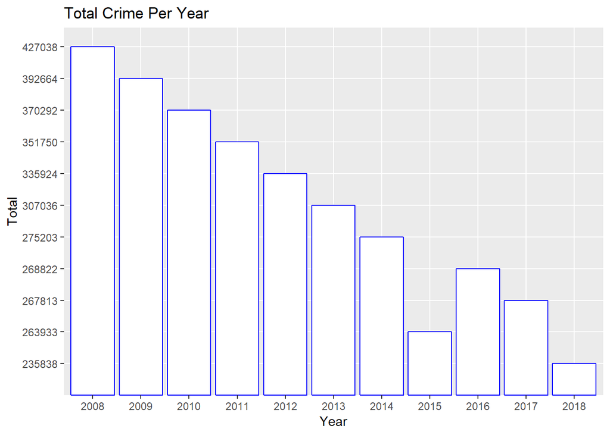

```r
ggplot(crime_year)+
  geom_bar(aes(as.character(Year), as.character(total)), stat= "identity",color = "blue",         fill ="white")+
  labs(x= "Year", y= "Total")+
  ggtitle("Total Crime Per Year")
```

The graphs gives a positive indication that the crime rate in Chicago has gone down considerably from the the year 2008 to the year 2018. Decreasing by almost half in 10 years.

### Number of crimes in each district

This graph will show us which districts in Chicago are safer compared to other

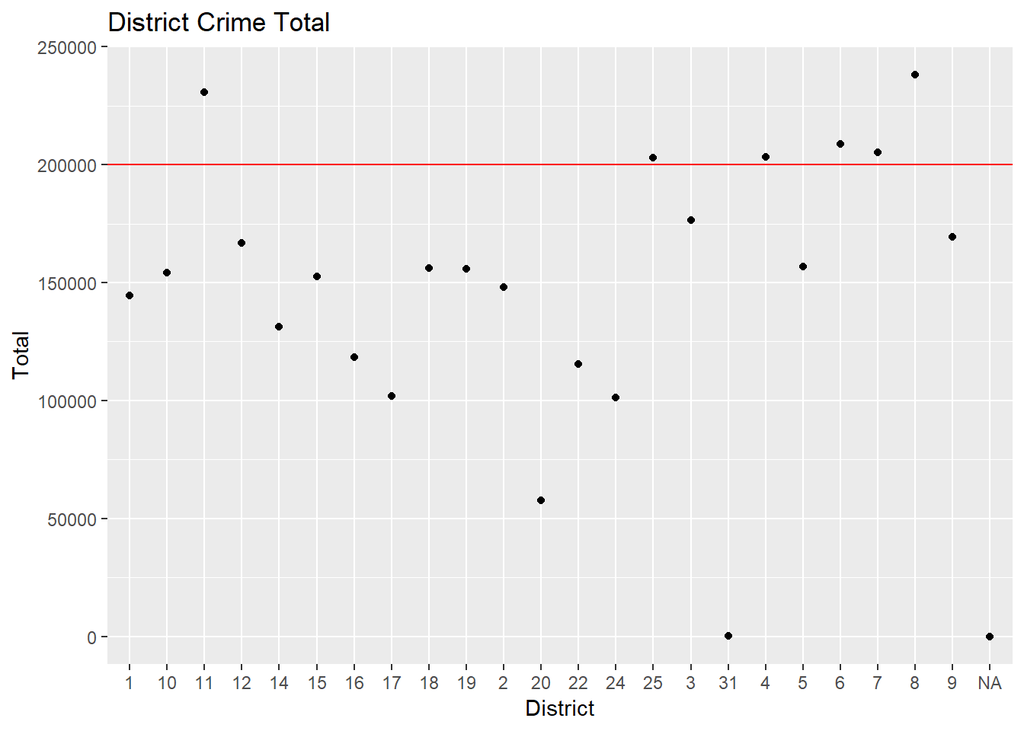

```r
ggplot(crime_district) +
  geom_point(mapping = aes(as.character(District), total)) +
  labs(x= "District", y="Total")+
  ggtitle("District Crime Total")+
  geom_hline(color = "red", yintercept = 200000)
```

This graph shows that there are 6 districts in the city of Chicago that have more than 200,000 reported crimes. Those are district numbers 4,6,7,8,11 and 25. With district number 8 being the most crime reported district in the city and the district number 31 being the safest district in the city.

### Type of crimes taking place and there frequency

This graph is a plot of the types of crimes that took place in Chicago and there frequency in the year of 2008.

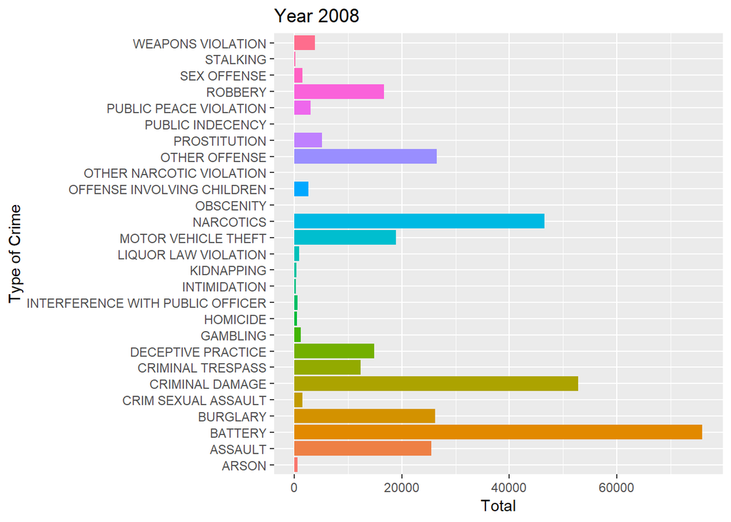

```r
chicagoClean%>%
  filter(Year == "2008")%>%
  filter(Primary.Type %in% c(violent, non_violent))%>%
  ggplot()+
   geom_bar(aes(x = Primary.Type, y = total, fill = Primary.Type), stat = "identity")+
  ggtitle("Year 2008")+
  labs(x = "Type of Crime", y = "Total")+
  theme(legend.position = "none")+
  coord_flip()
```

From the graph we can see that battery is the most frequently committed crime. Among violent crime, burglary was the most frequently committed crime in 2008.

This graph is a plot of the types of crimes that took place in Chicago and there frequency in the year of 2018.

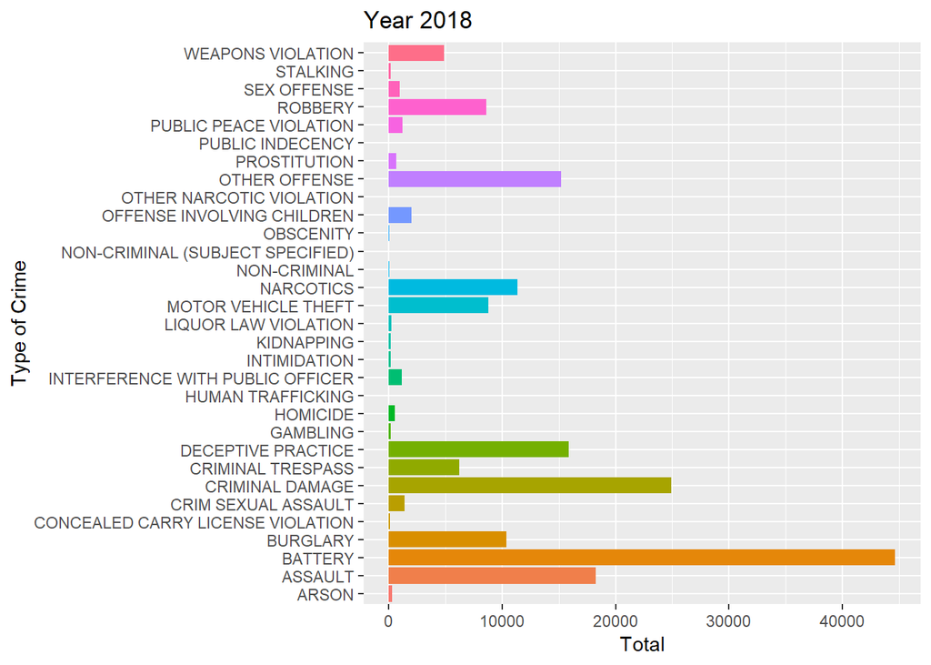

```r
chicagoClean%>%
  filter(Year == "2018")%>%
  filter(Primary.Type %in% c(violent, non_violent))%>%
  ggplot()+
   geom_bar(aes(x = Primary.Type, y = total, fill = Primary.Type), stat = "identity")+
  ggtitle("Year 2018")+
  labs(x = "Type of Crime", y = "Total")+
  theme(legend.position = "none")+
  coord_flip()
```

From the graph we can see that battery is still the most frequently committed crime in Chicago. The frequency although has gone down upon comparison to 2008. In the violent crime list however, assault is the most frequently committed violent crime in 2018 instead of burglary.

### Number of cases where an arrest was made

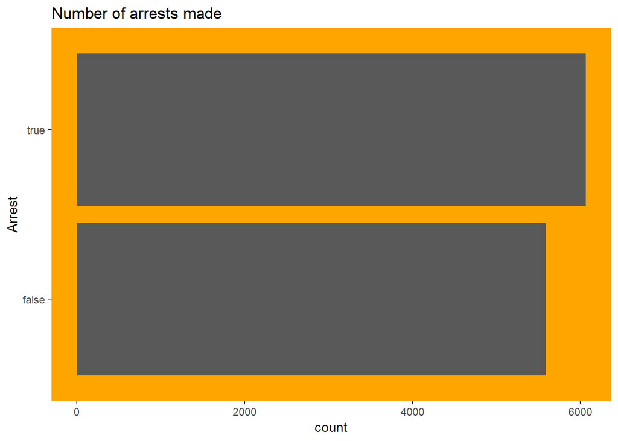

```r
chicagoClean %>%
  ggplot()+
  geom_histogram(mapping = aes(x= Arrest),stat = "count")+
  coord_flip()+
  ggtitle("Number of arrests made")+
  theme(panel.background = element_rect(fill = "Orange"),   panel.grid.major=element_blank(), panel.grid.minor = element_blank())
```

## Conclusion

Chicago as a city has had a past of being crime infested. The data shows us that the crime rate in Chicago is high and dangerous. With certain districts being more crime infested than others. However, from this study and the avialability of the data through Chicago Police Department, we can say that the crime in Chicago is going down considerably and Chicago as a city is becoming a lot safer. Crimes in Chicago have gone down by almost a half within the 10 years.

Also, from our research we see that in Chicago there are a few districts that people visiting Chicago and also people living in Chicago should avoid at best, or atleast be more cautious and attentive if at all they have to visit those areas.

Crimes like battery, deceptive practices, criminal damages, assault are highly frequent in Chicago as per the reports.

Having lived in Chicago in the past for 3 months, I have to admit Chicago is one of the greatest cities in the world. Looking at the progress made by the Chicago Police Department in controlling the crime in Chicago and results that we are seeing through this research, we can conclude that Chicago is on the right path to be one of the safer and better cities in the world.